# INTRODUCCIÓN A R

## ¿Qué es R Markdown?

Markdown es un lenguaje de marcado ligero creado por John Gruber que trata de conseguir la máxima legibilidad y facilidad de publicación tanto en su forma de entrada como de salida, inspirándose en muchas convenciones existentes para marcar mensajes de correo electrónico usando texto plano.

John Gruber creador de R-Markdown dice: "Que la utilidad de este se diferencia por dos cosas: **el lenguaje** y por otro lado, es una **herramienta de software** que convierte el lenguaje en HTML válido.

## Ventajas de utilizar R Markdown

**1 Escribir para web es más rápido y cómodo**

Una vez que te acostumbras y conoces mínimamente la sintaxis, completas el texto más rápido. Si lo que hacemos normalmente es seguir un proceso del tipo “escritura -> revisión -> formato”, las partes de revisión y formato las podemos hacer al mismo tiempo sin abandonar el teclado. Además, la sintaxis de **Markdown está pensada para que resulte más fácil de leer**. Es decir, que los elementos de formato no estorben la lectura, como sí ocurre en HTML.

**2 Correciones sintaxis**

El HTML básico, que es el que necesitamos para dar formato a un texto, es sumamente sencillo de usar. Pero también es muy fácil cometer errores. El más habitual: **olvidarse de cerrar** una etiqueta de manera adecuada. **Markdown hace que un error tan común como éste no se produzca**.

**3 Es perfecto para usarlo con editores de texto minimalistas**

A mucha gente le gusta escribir en texto plano, utilizando editores de texto o **procesadores minimalistas** por una cuestión de concentración: muchas veces, **no necesitamos tantas herramientas como las que nos ofrece un procesador como Word**, especialmente cuando todo lo que vamos a hacer es escribir un texto con un formato básico.

**4 Es ideal para el entorno móvil**

Si bien existen aplicaciones para dispositivos móviles que nos permiten aplicar formato a un texto, resulta *bastante incómodo* hacerlo por la misma naturaleza del sistema táctil. **Si usamos una aplicación que soporta Markdown, tan sólo se trata de escribir unos pocos caracteres más**. Es más rápido y ágil, especialmente si vamos aplicando el formato a medida que escribimos.

*En síntesis R-Markdown es un formato que permite una fácil creación de documentos, presentaciones dinámicas e informes de R.* **Markdown** es un formato de sintaxis simple para crear en **HTML, PDF, y Word**.

En el siguiente link pueden encontrar información de como se crean estos documentos [link](https://rstudio.com/wp-content/uploads/2015/03/rmarkdown-spanish.pdf)

## Expresiones Regulares

Es una notación de patrones de texto en contraposición a cadenas de caracteres exactas. La notación utiliza caracteres literales y metacaracteres. Cada carácter que no tiene un significado especial en la sintaxis de expresiones regulares es un carácter literal y coincide con una ocurrencia de ese carácter. **Por ejemplo**, letras y número son caracteres literales.

Un metacaracter es un símbolo con significado especial (un operador o delimitador) en la sintaxis de expresiones regulares.

| Caracter | Descripción |
| --- | --- |
| * | Repetir: cero o más ocurrencias de carácter o clase anteriores |
| ^ | Posición en la línea: comienzo de la línea |
| $ | Posición en la línea: fin de la línea |
| [class] | Clase de carácter: cualquier carácter de la serie |
| [^class] | Clase inversa: cualquier carácter que no esté en la serie |
| [x-y] | Intervalo: cualquier carácter que esté dentro del intervalo especificado |
| <xyz | Posición de palabra: principio de palabra |
| xyz> | Posición de palabra: fin de palabra |

Los fundamentos de las expresiones regulares. Son muy útiles y se emplean en muchos más lenguajes de programación

# ¿Cuáles son los tipos de expresiones regulares?

Se clasifican en tres tipos:

**Expresiones regulares POSIX extendida** [link](https://www.ibm.com/support/knowledgecenter/es/SS8NLW_12.0.0/com.ibm.swg.im.infosphere.dataexpl.engine.doc/c_posix-regex-examples.html)

**Expresiones regulares básicas** [link](https://indexingdata.com/blog/analitica-web/guia-basica-expresiones-regulares/)

**Expresiones regulares de Perl** [link](http://www2.iib.uam.es/bioinfo/curso/perl/tutoriales/cicei/cap6.htm)

Por último las expresiones regulares pueden ser de gran utilidad en análisis de secuencias en donde se realiza un gran número de tareas relacionadas con la búsqueda y la sustitución o extracción de cadenas de un texto.

# Ejemplos en R Markdown con:

## plot

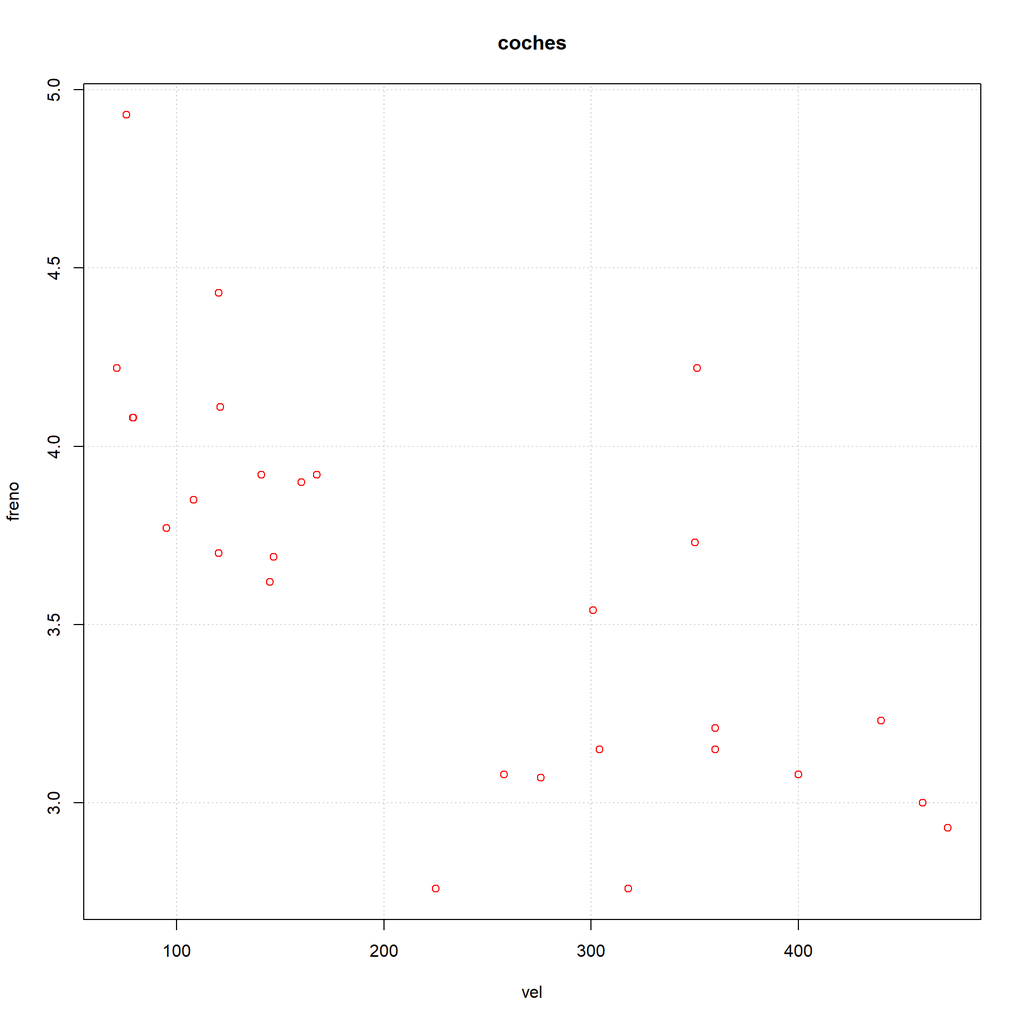

## Gráficas en ggplot2

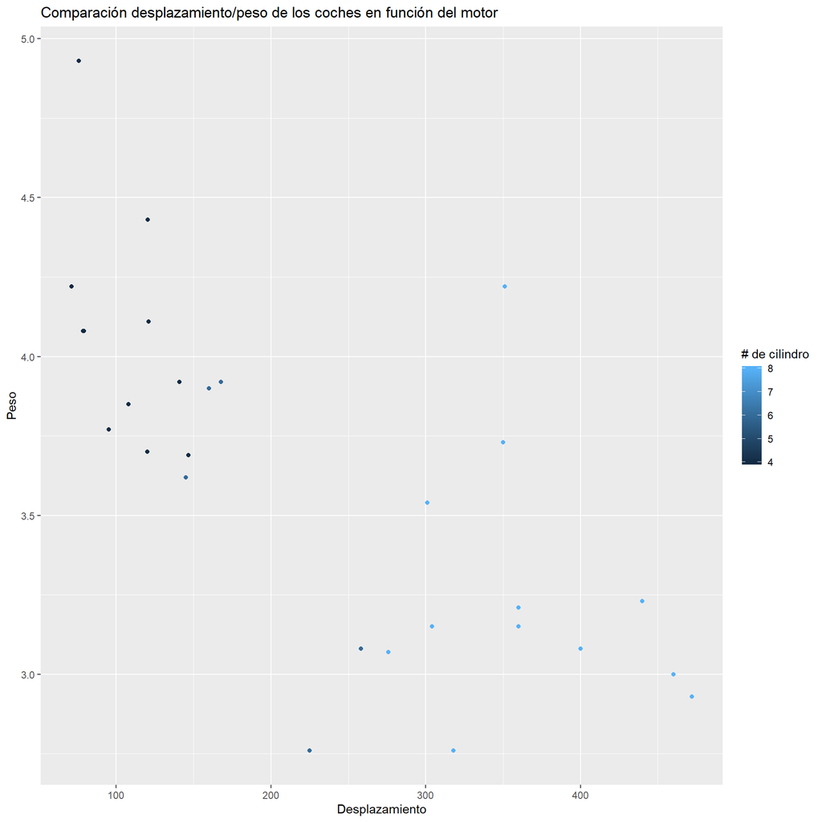

Maria Alejandra Quintero Ferro